# Eksplorasi Data Adjusted Closing Price IHSG

Kelompok 14

## Anggota Kelompok

- G14190007 Dhiffa Fatihah Umami
- G14190026 Nenden Maulidia
- G14190043 Tony Alfan
- G14190047 Alvin Christian
- G14190071 Muhammad Hadyan Rizki

## IHSG

Indeks Harga Saham Gabungan (IHSG) merupakan catatan-catatan atas perubahan maupun pergerakan harga saham sejak mulai pertama kali beredar sampai pada suatu saat tertentu. Ada beberapa faktor yang mempengaruhi IHSG, salah satunya adalah faktor makroekonomi seperti tingkat inflasi, nilai tukar rupiah, tingkat suku bunga dan lain-lain (Krisna dan Wirawati 2013).

Indeks Harga Saham Gabungan (IHSG) merupakan suatu nilai untuk mengukur kinerja seluruh saham. IHSG mencerminkan perkembangan pasar secara keseluruhan. Jika IHSG mengalami kenaikan dari hari kemarin maka beberapa saham yang berada pada bursa efek mengalami kenaikan. Oleh karena itu, peramalan harga akan sangat bermanfaat untuk para investor sehingga mereka dapat mengetahui prospek investasi saham di masa yang akan datang (Afittia 2018).

- Bursa Efek Indonesia tidak dibuka pada hari sabtu dan minggu
- Bursa Efek Indonesia tidak dibuka pada tanggal merah

Mengapa perlu dilakukan imputasi? Karena pada hari sabtu & minggu dan pada tanggal merah, masyarakat tetap dapat memiliki perubahan opini terhadap harga saham. Contohnya, perusahaan X terkena kasus pada hari sabtu, maka masyarakat akan cenderung memberikan harga lebih kecil terhadap saham perusahaan X sehingga ketika pasar saham dibuka, harga saham perusahaan X akan langsung menurun. Hal ini juga diperkuat fakta bahwa analisis time series memerlukan seluruh amatan secara lengkap. Metode imputasi yang kami gunakan adalah dengan interpolasi linear.

Harga saham yang akan diamati adalah Adjusted Closing Price (harga closing yang sudah disesuaikan). Harga closing hanya menyatakan harga terakhir ketika pasar saham ditutup. Sedangkan harga closing yang telah disesuaikan mempertimbangkan faktor lain seperti dividen, stock splits, dan penawaran saham baru.

## Import data dan Libraries

Importing libraries

```r
library(aTSA)
library(imputeTS)
library(knitr)
library(MASS)
```

Import data dan melihat 10 data pertama.

```r
ihsg <- read.csv("C:/Users/Haci/Desktop/Metode Peramalan Deret Waktu/Project-20220127/IHSG7days.csv", sep=";")
kable(ihsg[1:10,], caption="First 10 rows of IHSG daily prices")
```

First 10 rows of IHSG daily prices

| date | JKSE.Adjusted |
| --- | --- |
| 01/01/1991 | NA |
| 02/01/1991 | NA |
| 03/01/1991 | 408.538 |
| 04/01/1991 | 408.491 |
| 05/01/1991 | NA |
| 06/01/1991 | NA |
| 07/01/1991 | 404.817 |
| 08/01/1991 | 401.647 |
| 09/01/1991 | 399.133 |
| 10/01/1991 | 397.383 |

Dari 10 data pertama, dapat dilihat bahwa terdapat beberapa missing values. Pasar Saham tidak dibuka pada hari sabtu-minggu dan tanggal merah, sehingga dapat dipastikan akan terdapat missingvalue tiap minggunya. Maka akan dilakukan interpolasi untuk mengatasi missing value tersebut.

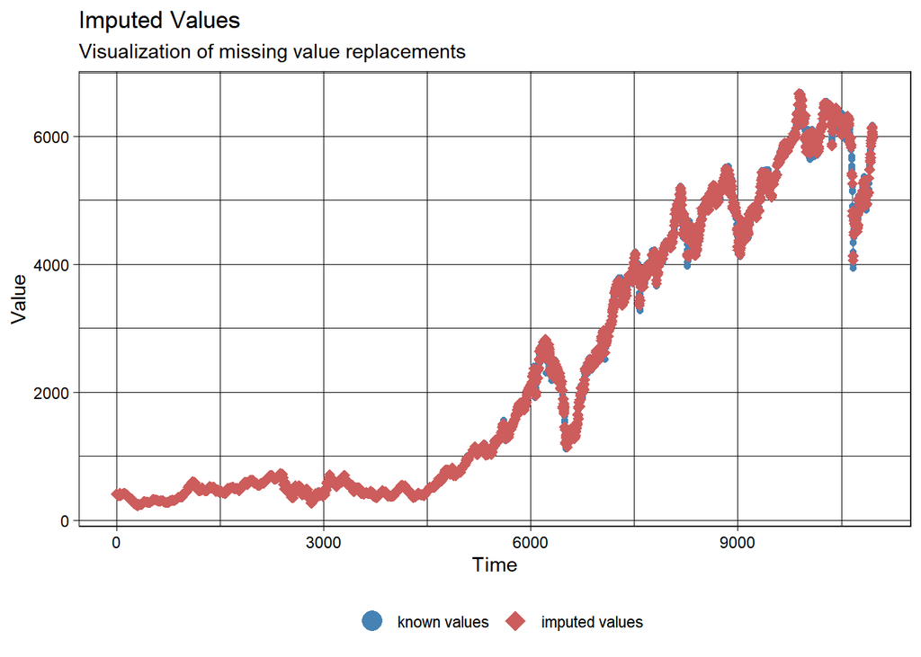

```r
ihsg.imputed <- na_interpolation(ihsg)
ggplot_na_imputations(ihsg$JKSE.Adjusted, ihsg.imputed$JKSE.Adjusted)
```

Dapat kita lihat bahwa imputasi tidak mengubah tren dari harga Adjusted Closing Price. Mari kita coba amati plot time series dari Adjusted Closing Price harian IHSG.

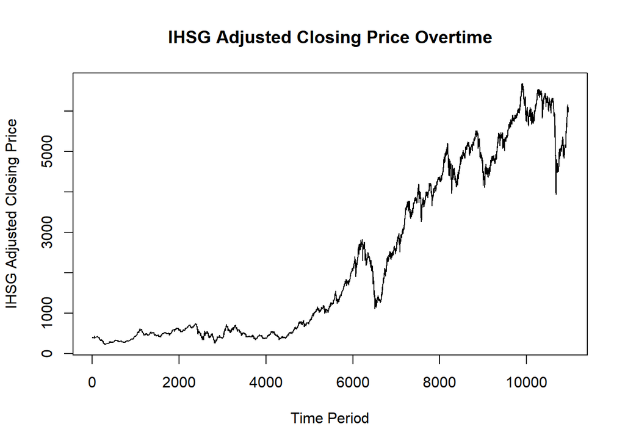

```r
ihsg.ts <- ts(ihsg.imputed$JKSE.Adjusted)
ts.plot(ihsg.ts, xlab="Time Period", ylab="IHSG Adjusted Closing Price",
        main="IHSG Adjusted Closing Price Overtime")
```

Berdasarkan plot time series, terlihat bahwa data yang kita miliki tidak stasioner secara rataan maupun secara ragama. Dapat diamati lebih lanjut dengan plot ACF dan PACF.

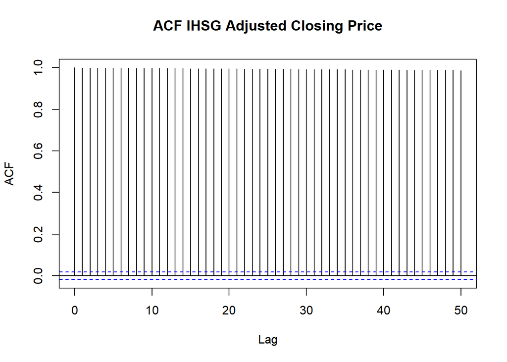

```r
acf(ihsg.ts, lag.max = 50, main = "ACF IHSG Adjusted Closing Price")
```

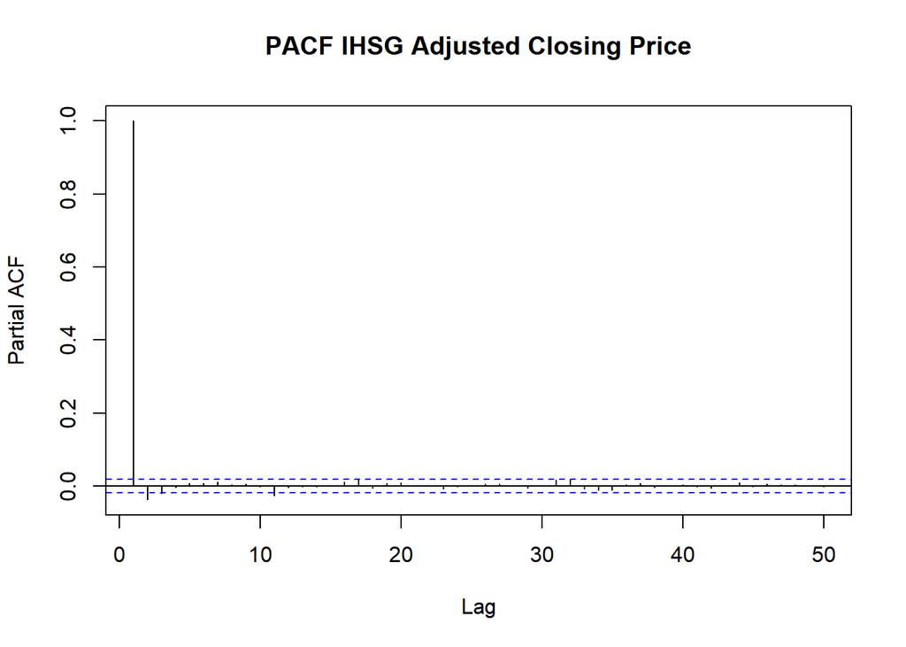

```r
pacf(ihsg.ts, lag.max = 50, main = "PACF IHSG Adjusted Closing Price")
```

```r
adf.test(ihsg.ts)
```

```
## Augmented Dickey-Fuller Test
## alternative: stationary
##
## Type 1: no drift no trend
##       lag  ADF p.value
##  [1,]   0 1.79   0.982
##  [2,]   1 1.46   0.963
##  [3,]   2 1.38   0.958
##  [4,]   3 1.44   0.961
##  [5,]   4 1.47   0.964
##  [6,]   5 1.51   0.967
##  [7,]   6 1.57   0.971
##  [8,]   7 1.57   0.971
##  [9,]   8 1.59   0.973
## [10,]   9 1.59   0.973
```

[output cut: 32 more lines]

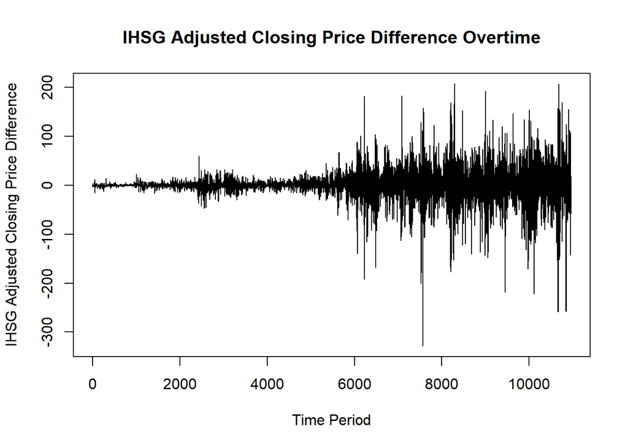

```r
ihsg.diff <- diff(ihsg.ts, difference=1)
ts.plot(ihsg.diff, xlab="Time Period", ylab="IHSG Adjusted Closing Price Difference", main="IHSG Adjusted Closing Price Difference Overtime")
```

Dari plot time series, terlihat bahwa data IHSG yang telah didifferencingkan telah stasioner secara rataan namun tidak dalam ragam. Hal ini dapat dilihat lebih lanjut dengan plot ACF dan PACF dan dengan uji ADF.

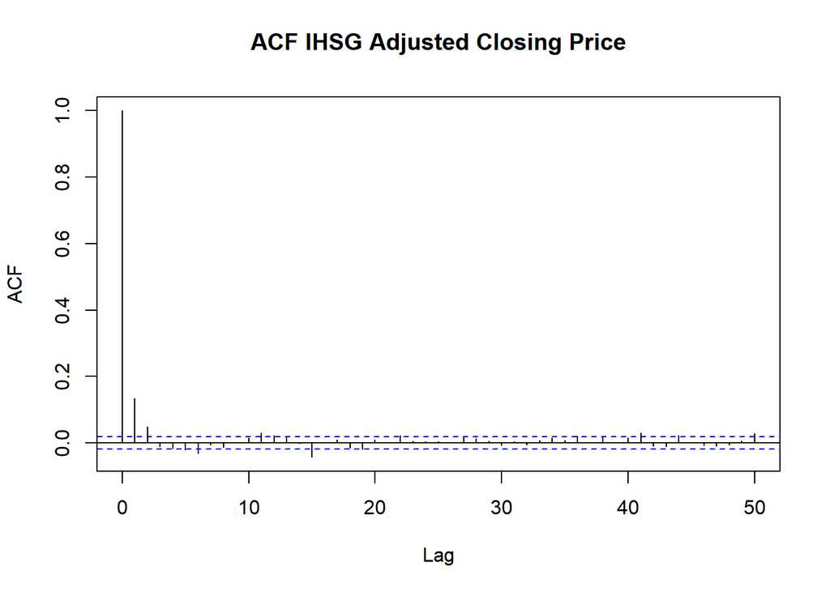

```r
acf(ihsg.diff, lag.max = 50, main = "ACF IHSG Adjusted Closing Price")
```

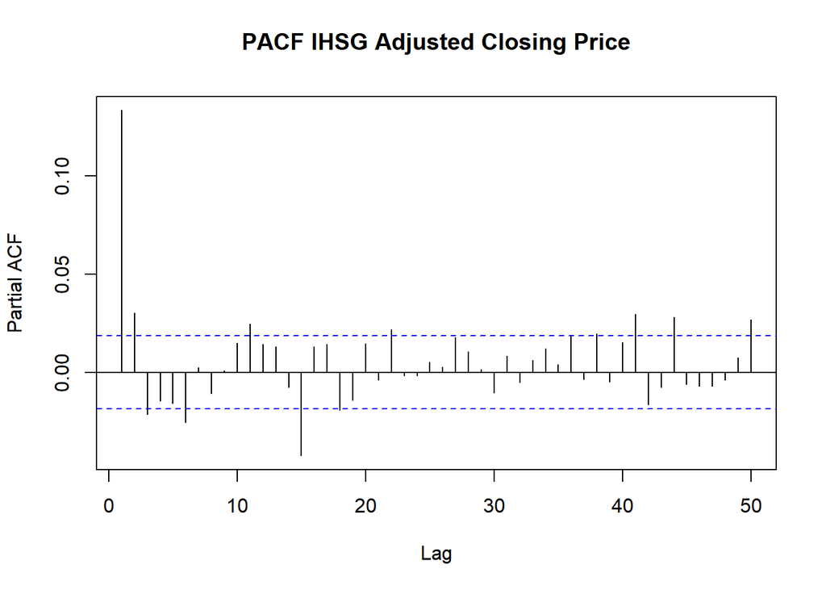

```r
pacf(ihsg.diff, lag.max = 50, main = "PACF IHSG Adjusted Closing Price")
```

```r
adf.test(ihsg.ts)
```

```
## Augmented Dickey-Fuller Test
## alternative: stationary
##
## Type 1: no drift no trend
##       lag  ADF p.value
##  [1,]   0 1.79   0.982
##  [2,]   1 1.46   0.963
##  [3,]   2 1.38   0.958
##  [4,]   3 1.44   0.961
##  [5,]   4 1.47   0.964
##  [6,]   5 1.51   0.967
##  [7,]   6 1.57   0.971
##  [8,]   7 1.57   0.971
##  [9,]   8 1.59   0.973
## [10,]   9 1.59   0.973
```

[output cut: 32 more lines]

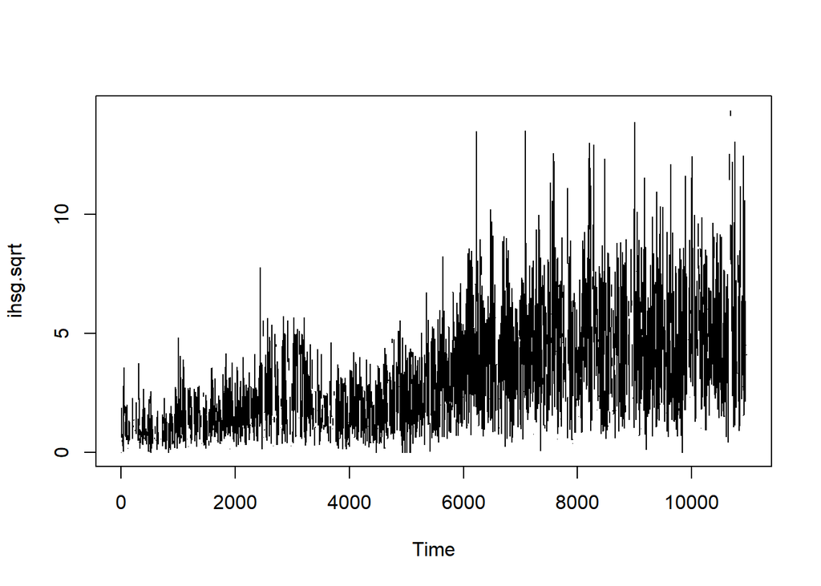

```r
ihsg.sqrt <- ihsg.diff^(1/2)
ihsg.cbrt <- ihsg.diff^(1/3)
ihsg.log <- log(ihsg.diff+abs(min(ihsg.diff)))
ihsg.inv <- -1/ihsg.diff

ts.plot(ihsg.sqrt)
```

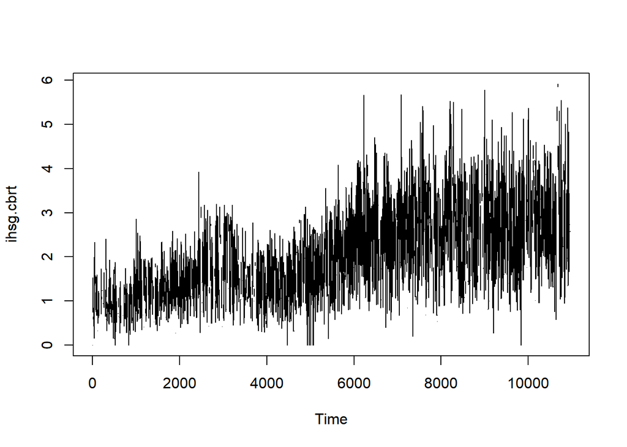

```r
ts.plot(ihsg.cbrt)
```

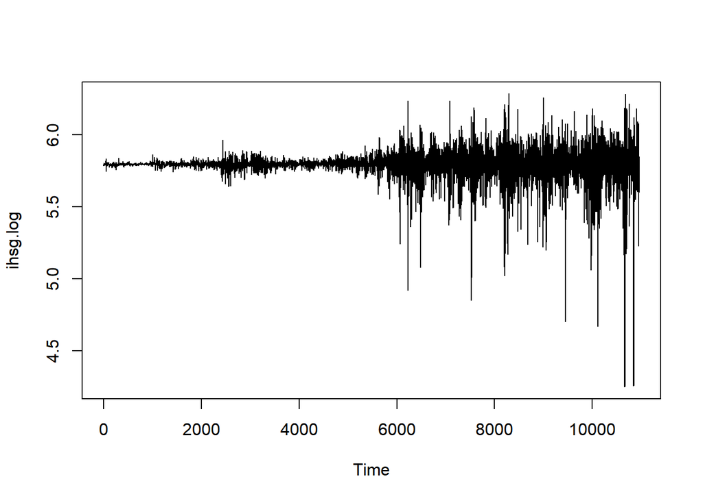

```r
ts.plot(ihsg.log)
```

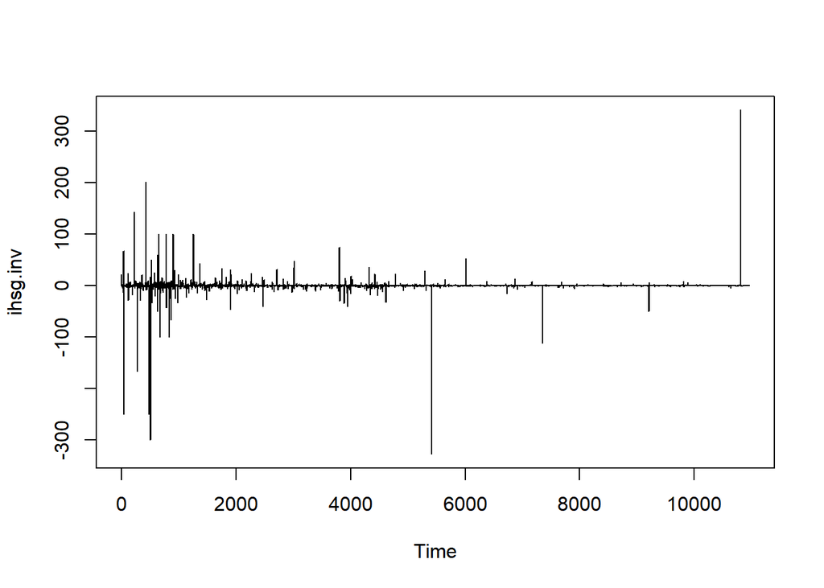

```r
ts.plot(ihsg.inv)
```

```r
minvalue <- abs(min(ihsg.diff))+1
bcd <- boxcox((ihsg.diff+minvalue) ~ 1)
```

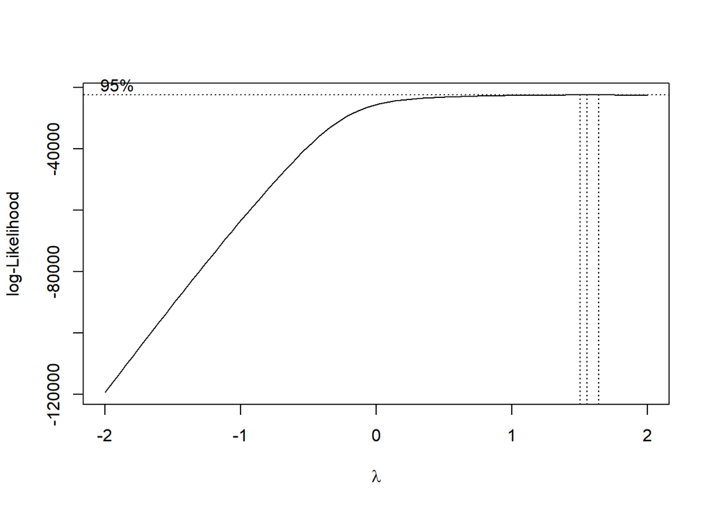

```r
lambda <- bcd$x[which.max(bcd$y)]; lambda
```

```
## [1] 1.555556
```

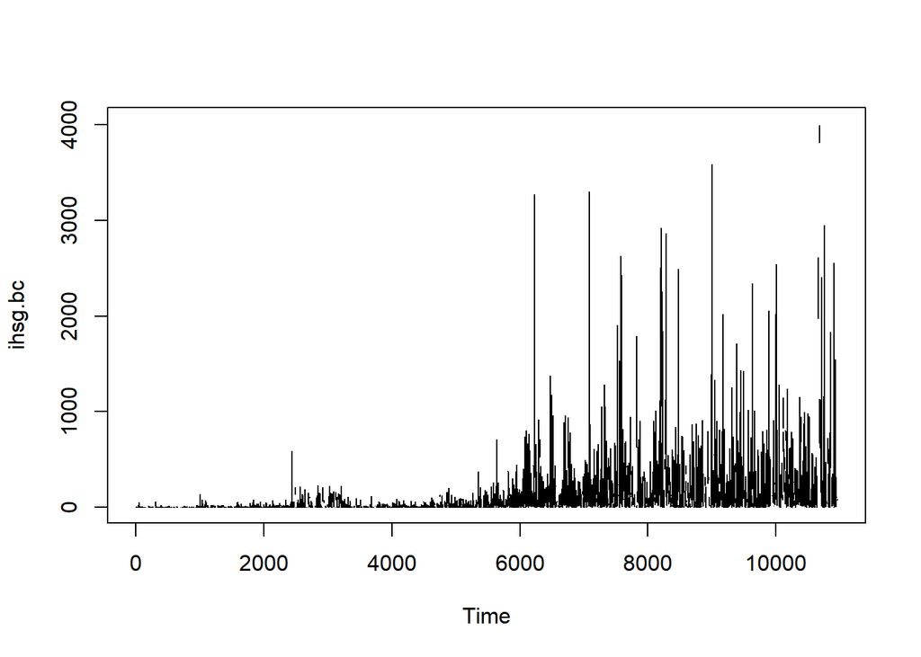

```r
ihsg.bc <- ihsg.diff^(lambda)
ts.plot(ihsg.bc)
```

Tidak ada transformasi yang sukses menyelesaikan permasalahan ragam yang tidak stasioner. Transformasi BoxCox juga sudah dicoba namun belum dapat menyelsaikan juga.

Salah satu dugaan adalah keragaman tersebut timbul akibat adanya inflasi karena periode waktu yang digunakan cukup besar yaitu 30 tahun, maka pengaruh inflasi terhadap fluktuasi harga sama mungkin mengakibatkan keragaman yang lebih besar.

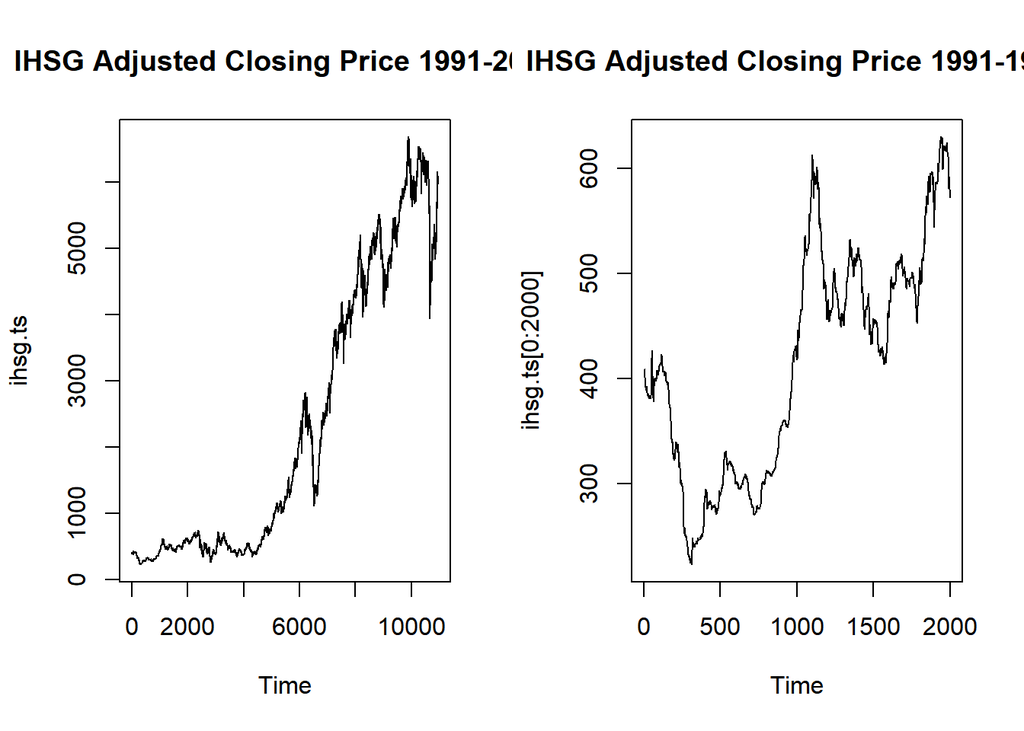

```r
par(mfrow=c(1,2))
ts.plot(ihsg.ts, main="IHSG Adjusted Closing Price 1991-2020")
ts.plot(ihsg.ts[0:2000], main="IHSG Adjusted Closing Price 1991-1996")
```

Dapat kita lihat bahwa jika dibandingkan secara berdampingan, terlihat sebenarnya data dari tahun 1991-1996 juga mengalami fluktuasi yang cukup besar. Namun pada plot data dari tahun 1991-2020, fluktuasi/perubahan harga saham harian pada tahun 1991-1996 tidak begitu terlihat. Hal ini sangat mungkin disebabkan inflasi sehingga harga saham tahun 1991-1996 jika dibandingkan tahun 2010 ke atas akan terlihat tidak begitu beragam.

## References

Afittia W. 2018. Penerapan Metode Eksponensial Smoothing untuk Meramalkan Indeks Harga Saham Gabungan pada Tahun 2018-2020. Medan (ID) : Universitas Sumatera Utara.

Krisna AAGD, Wirawati NGP. 2013. Pengaruh inflasi, nilai tukar rupiah, suku bunga sbi pada indeks harga saham gabungan di bei. E-Jurnal Akuntansi. 3(2) : 421-435.